# STA257

Last edited: 2016-10-19 15:05

## time to first event of a Poisson process

Let's say we have a Poisson process \(N(t)\) with rate \(\lambda\). The time of the first event is random. Call this time \(X\).

What can we say about \(X\)? Can we completely describe its distribution?

Yes, because \(F(x) = 1 - P(X > x)\) and \(\{X > x\}\) *is exactly equivalent to* \(\{N(x) \le 0\}\), so we can derive the cdf for \(X\).

\[F(x) = P(X \le x) = \begin{cases} 0 &: x \le 0\\ 1 - e^{-\lambda x} &: x > 0\\ \end{cases}.\] So the density is: \[f(x) = F'(x) = \begin{cases} \lambda e^{-\lambda x} &: x > 0\\ 0 &: \text{otherwise}. \end{cases}\]

## the exponential distributions

In this case we say \(X\) has an exponential distribution with (rate) parameter \(\lambda\), or \(X \sim\text{Exp}(\lambda)\).

Free picture for Exp\((1)\) density:

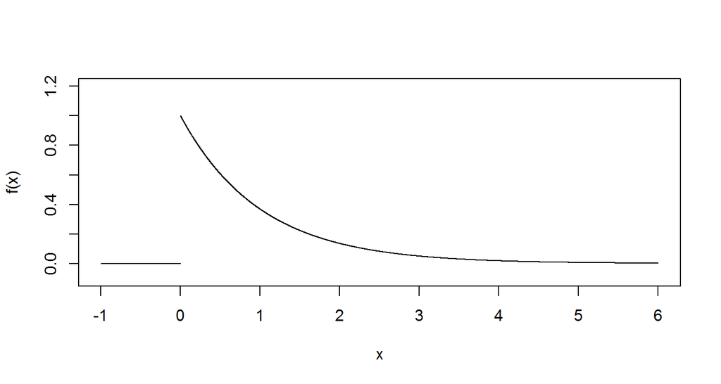

## what should we expect of a Poisson waiting time?

The Poisson process is the continuous time analogy of the Bernoulli process. Both intended to be "completely random" (process is memoryless and counts over disjoint intervals are independent.)

The exponential distributions, like the geometric, turn out to be memoryless.

But wait! There's more!

Theorem: The exponential distributions are the *only* continuous, memoryless distributions.

Proof: …

## exponential example

The exponential distributions are commonly used as a model of "completely random failure". Examples include complex systems, electronic devices, and many others.

Suppose a haul truck diesel engine has a failure time \(X\) modeled using an exponential distribution. The rate is 1 failure every 5 years.

What is the probability that an engine will survive more than 3 years?

What is the probability that, out of a fleet of \(n=20\) engines, more than half will survive more than 3 years? (Assume independent failures.)

## time to \(n^{th}\) event of a Poisson process

Let's say we have a Poisson process \(N(t)\) with rate \(\lambda\). The time of the first \(n^{th}\) event is random. Call this time \(X\).

What can we say about \(X\)? Can we completely describe its distribution?

Yes, because \(F(x) = 1 - P(X > x)\), and \(\{X > x\}\) *is exactly equivalent to* \(\{N(x) \le n-1\},\) so we can derive the cdf for \(X\).

\[F(x) = P(X \le x) = \begin{cases} 0 &: x \le 0\\ 1 - \sum_{i=0}^{n-1} \frac{[\lambda x]^{i}}{i!}e^{-\lambda x} &: x > 0\\ \end{cases}.\] So the density is (after some fussy work): \[f(x) = F'(x) = \begin{cases} \frac{\lambda^n}{(n-1)!} x^{n-1} e^{-\lambda x} &: x > 0\\ 0 &: \text{otherwise}. \end{cases}\]

## generalization: the gamma distributions

Definition: the *gamma function* is defined as: \[\Gamma(\alpha) = \int_0^\infty u^{\alpha-1}e^{-u}\,du, \qquad \alpha > 0.\] Many interesting properties, including \(\Gamma(n) = (n-1)!\) for integer \(n\ge 1\) (exercise 49 in book.)

The following function is a valid density for \(\alpha > 0\) and \(\lambda > 0\): \[f(x) = \begin{cases} \frac{\lambda^\alpha}{\Gamma(\alpha)}x^{\alpha-1}e^{-\lambda x} &: x > 0\\ 0 &: \text{ otherwise}.\end{cases}\] Proof: …

## free pictures of some Gamma(\(\alpha\), 1) densities

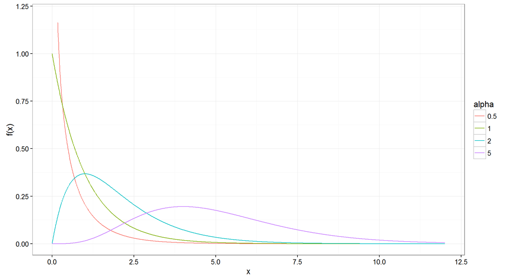

## gamma distribution trivia

We can say \(X\) has a gamma distribution with "shape parameter"" \(\alpha\) and "rate parameter" \(\lambda\), or \(X\sim\text{Gamma}(\alpha,\lambda)\).

Lots of things seem to (empirically) have gamma distributions: insurance claim amounts, crack growth models, earthquake times, neuron spike, etc.

Special cases: \(\alpha = 1\) is exponential.

\(\alpha = n\) positive integer gives the *waiting time until the \(n\)th event in a Poisson process* (also called "Erlang\((n,\lambda)\)")

\(\alpha = n/2\) and \(\lambda = 1/2\) is called \(\chi^2_n\) and has applications in statistics. (More later.)

## another fun Poisson process fact

Suppose at some fixed time \(t\) of a Poisson process we know \(N(t)=1\). In other words, exactly one "event" occured at some time before \(t\).

This occurrence time is a random variable. Call it \(X\). What is its distribution?

Let's try to derive its cdf:

\[F(x) = P(X \le x) = \begin{cases} 0 &: x < 0\\ ??? &: 0 \le x \le t\\ 1 &: x \ge t\end{cases}\]

## exercise

Suppose at some fixed time \(t>0\) of a Poisson process we know \(N(t)=n\).

Fix another time \(s\) with \(0 < s < t\).

Find the distribution of the number \(X\) of events that occurred inside \([0,s]\).

## (not done in class) \(n^{th}\) event density fussy work

\[\begin{align} \frac{d}{dx} \left(1 - \sum_{i=0}^{n-1} \frac{[\lambda x]^{i}}{i!}e^{-\lambda x}\right) &= - \frac{d}{dx} \left(e^{-\lambda x}\sum_{i=0}^{n-1} \frac{[\lambda x]^{i}}{i!}\right)\\ &= -\left(-\lambda e^{-\lambda x}\sum_{i=0}^{n-1} \frac{[\lambda x]^{i}}{i!} + e^{-\lambda x}\sum_{i=1}^{n-1} \frac{\lambda [\lambda x]^{i-1}}{(i-1)!} \right)\\ &= \lambda e^{-\lambda x} \left(\sum_{i=0}^{n-1} \frac{[\lambda x]^{i}}{i!} - \sum_{i=1}^{n-1} \frac{ [\lambda x]^{i-1}}{(i-1)!} \right)\\ &=\lambda e^{-\lambda x} \left(\sum_{i=0}^{n-1} \frac{[\lambda x]^{i}}{i!} - \sum_{i=0}^{n-2} \frac{ [\lambda x]^{i}}{(i)!} \right)\\ &=\frac{\lambda^n}{(n-1)!}x^{n-1}e^{-\lambda x} \end{align}\]